# Reanalysis of BELIV Paper Study Data

Robert Kosara

July 10, 2016

For [a paper at BELIV 2010](http://kosara.net/publications/Kosara_BELIV_2010.html), Caroline Ziemkiewicz and I ran a study on Mechanical Turk that was among the first visualization studies run there. We decided to do a quick study of different chart types to see how well it would work.

This is a reanalysis of the data in light of [the more recent pie chart studies](https://eagereyes.org/blog/2016/an-illustrated-tour-of-the-pie-chart-study-results) by Drew Skau and me.

## Data

First, reading in the data and doing a bit of work to calculate error and reorder and rename the charts. We called the study *simplevis* back then, so *sv* is the prefix for the datasets.

```r
library(dplyr)
```

```r
sv <- read.csv("data/simplevis.csv") %>%
    mutate(error = Estimate-Value,
           Type = factor(Type,
                      levels=c("squarepie", "bars", "piechart", "donut"),
                      labels=c("Square Pie", "Bar Chart", "Pie Chart", "Donut Chart")),
           Confidence = factor(Confidence,
                            levels=c("low", "medium", "high"),
                            labels=c("Low", "Medium", "High")))
```

Aggreagate by participant and chart type. This calculates mean error and mean absolute error.

```r
svAgg <- group_by(sv, ID, Type) %>%
    summarize(meanError = mean(error),
                meanAbsError = mean(abs(error)))
```

## Helper Functions

The first two functions below are helpers that calculate the lower and upper bounds of the confidence interval. `plotCIs` creates the plots.

```r
library(ggplot2)

lowerCI <- function(v) {
    mean(v) - sd(v)*1.96/sqrt(length(v))
}

upperCI <- function(v) {
    mean(v) + sd(v)*1.96/sqrt(length(v))
}

plotCIs <- function(dataFrame, x_variable, y_variable, label, zeroLine=NA) {
    p <- ggplot(dataFrame, aes(x=x_variable, fill=x_variable, y=y_variable))
    if (!is.na(zeroLine)) {
        p <- p + geom_hline(yintercept=0, linetype=zeroLine)
    }
    p <- p +
        stat_summary(fun.ymin=lowerCI, fun.ymax=upperCI, geom="errorbar", aes(width=.1)) +
        stat_summary(fun.y=mean, geom="point", shape=18, size=3, show.legend = FALSE) +
        labs(x = NULL, y = label)

    p
}
```

## Plotting the Data

Now the plots! First up, signed error for all four chart types, which shows bias.

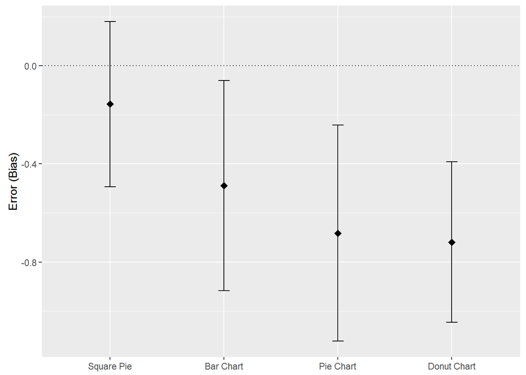

```r
plotCIs(svAgg, svAgg$Type, svAgg$meanError, "Error (Bias)", 'dotted')
```

Next, absolute error, which shows precision.

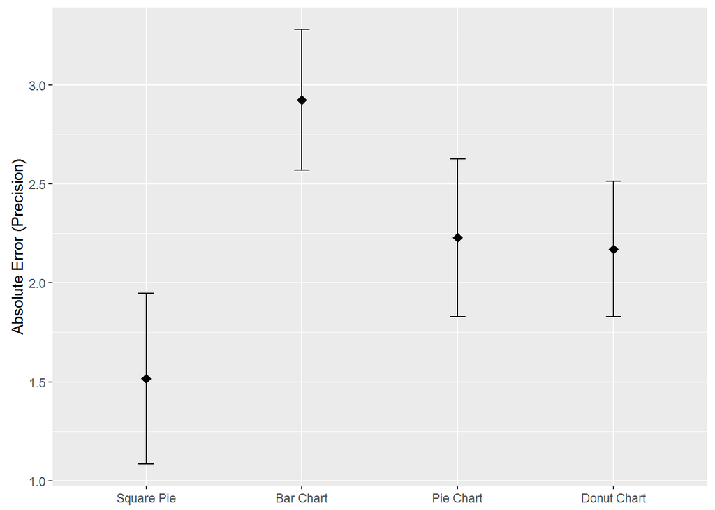

```r
plotCIs(svAgg, svAgg$Type, svAgg$meanAbsError, "Absolute Error (Precision)")
```

## Choose Square Pie as Baseline

Now we create a separate data frame that has just the square pie values, and then join that back with the other data and calculate the difference between each of the chart types and the square pie. This lets us compare the other chart types to the square pie by looking at whether their confidence intervals cross the zero line.

```r
svSquarePies <- filter(svAgg, Type == "Square Pie") %>%
    select(ID,
           sqpie_meanError = meanError,
           sqpie_meanAbsError = meanAbsError,
           t = Type)

svJoined <- left_join(svSquarePies, svAgg) %>%
    mutate(sqpieDifferenceMeanError = meanError-sqpie_meanError,
           sqpieDifferenceMeanAbsError = meanAbsError-sqpie_meanAbsError)
```

First again the signed error or bias.

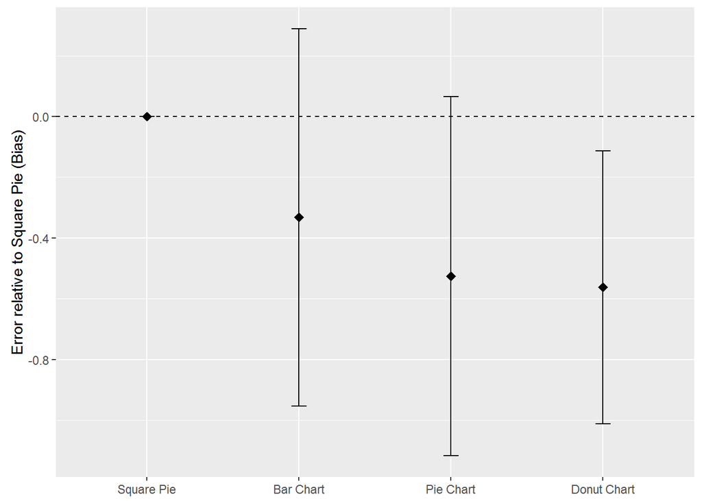

```r
plotCIs(svJoined, svJoined$Type, svJoined$sqpieDifferenceMeanError, "Error relative to Square Pie (Bias)", 'dashed')
```

Next the absolute error, or precision.

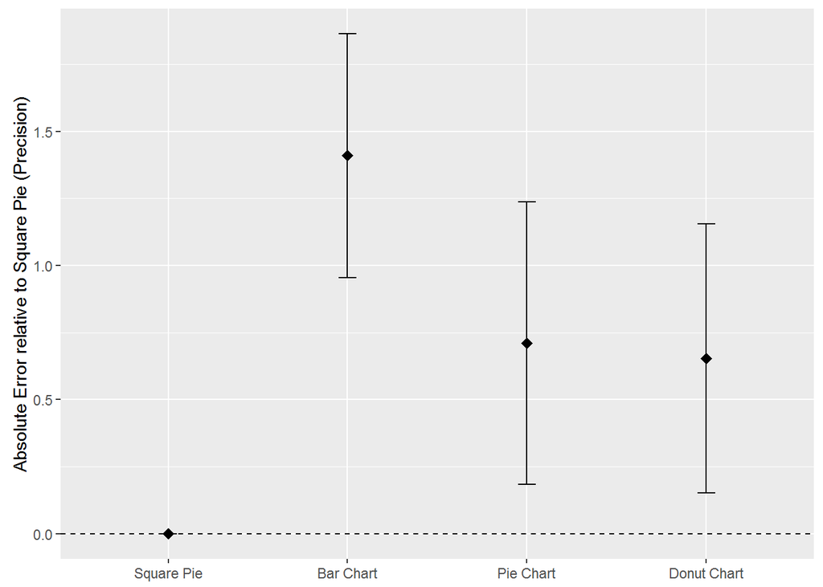

```r
plotCIs(svJoined, svJoined$Type, svJoined$sqpieDifferenceMeanAbsError, "Absolute Error relative to Square Pie (Precision)", 'dashed')
```

## Confidence

It’s also intersting to look at the confidence. People had much higher confidence in their guesses with the square pie, less with the pie and donut, and least with the stacked bar!

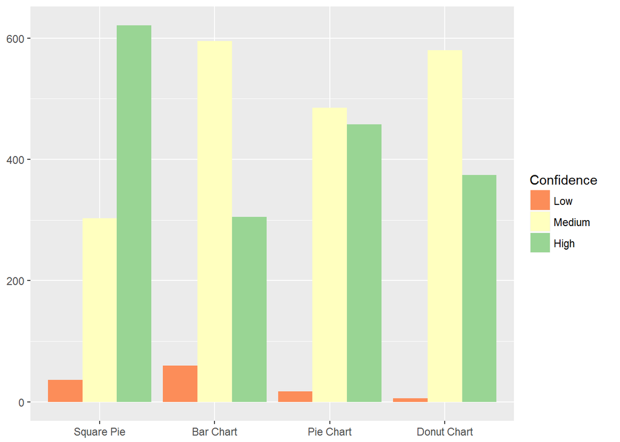

```r
ggplot(sv, aes(x=Type, fill=Confidence)) +
    geom_bar(stat="count", position=position_dodge()) +
    scale_fill_brewer(palette="Spectral") +
    labs(x=NULL, y=NULL)
```

## Comparison with Arcs, Angles, Areas Study

To compare with the more recent study, we load in the arcs-angles-areas dataset. This requires some work to rename variables. Both datasets are reduced to the minimum set of columns to reduce merging issues.

```r
aaa <- read.csv("data/arcs-angles-areas-merged.csv") %>%
    filter(chart_type == 'Pie Chart' | chart_type == 'Donut Chart') %>%
    mutate(chart_type = factor(chart_type,
                               levels=c('Pie Chart', 'Donut Chart'),
                      labels=c('Pie AAA', 'Donut AAA')),
           error = ifelse(log_error == log_opposite, judged_true, (100-ans_trial)-correct_ans),
           subjectID = factor(subjectID)
    ) %>%
    select(ID = subjectID, Type = chart_type, error)

aaaAggregated <- aaa %>%
    group_by(Type, ID) %>%
    summarize(meanError = mean(error),
              meanAbsError = mean(abs(error)))

svReduced <- select(svAgg, ID, Type, meanError, meanAbsError)
```

Now we merge them and reorder the combined `Type` column for better charts.

```r
svAAAMerged <- bind_rows(svReduced, aaaAggregated) %>%
    mutate(Type = factor(Type,
                      levels=c("Square Pie", "Bar Chart", "Pie Chart", "Donut Chart", "Pie AAA", "Donut AAA")))
```

Comparison time! Signed error first again.

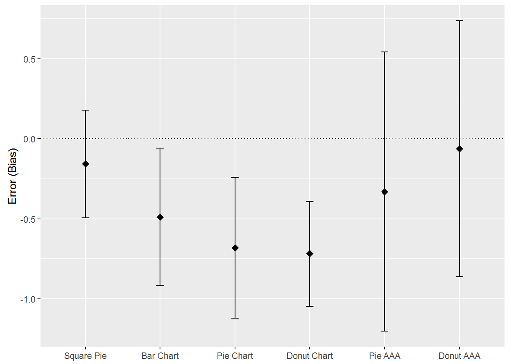

```r
plotCIs(svAAAMerged, svAAAMerged$Type, svAAAMerged$meanError, "Error (Bias)", 'dotted')
```

Absolute error.

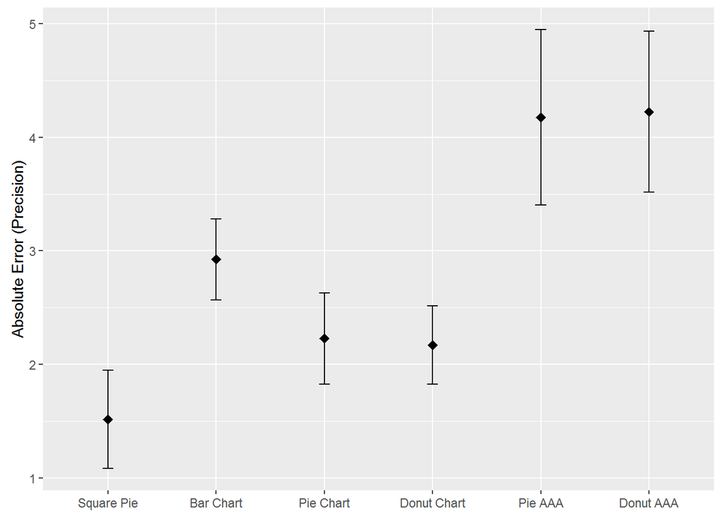

```r
plotCIs(svAAAMerged, svAAAMerged$Type, svAAAMerged$meanAbsError, "Absolute Error (Precision)")
```

Oddly, the error in the more recent study is much higher than in the first one. The two chart types behave the same in each of them, though.